# AMAZON PROJECT

## WOMEN DRESS AMAZON REVIEWS

## TABLE OF CONTENTS

[output not shown]

## COLUMN DESCRIPTION

| Column Name | Description |
| --- | --- |
| age | Age of the reviewer |
| division_name | Broad division category (e.g., General, General Petite, Intimates) |
| department_name | Department in which the clothing item falls (e.g., Bottoms, Tops) |
| class_name | Specific clothing class (e.g., Jeans, Dresses, Blouses) |
| clothing_id | Unique identifier for each clothing product |
| title | Short title or summary of the review |
| review_text | The full review text written by the customer |
| alike_feedback_count | Number of users who found the review helpful |
| rating | Star rating given by the reviewer (typically 1 to 5) |
| recommend_index | Indicates whether the reviewer recommends the product (1 = Yes, 0 = No) |

## LOADING LIBRARIES

```python
# 1. Import Libraries
import pandas as pd
import numpy as np
import matplotlib.pyplot as plt
import seaborn as sns
import re
import string
from textblob import TextBlob
from wordcloud import WordCloud
from sklearn.model_selection import train_test_split
from sklearn.feature_extraction.text import TfidfVectorizer
from sklearn.linear_model import LogisticRegression
from sklearn.naive_bayes import MultinomialNB
from sklearn.metrics import accuracy_score, classification_report, confusion_matrix
from sklearn.linear_model import LogisticRegression
from sklearn.tree import DecisionTreeClassifier
from sklearn.ensemble import RandomForestClassifier
from sklearn.linear_model import LogisticRegression
from xgboost import XGBClassifier
from sklearn.svm import LinearSVC

# 2. Download necessary NLTK resources
import nltk
from nltk.corpus import stopwords
from nltk.tokenize import word_tokenize
from nltk.stem import WordNetLemmatizer
from sklearn.feature_extraction.text import TfidfVectorizer
nltk.download('punkt')
nltk.download('stopwords')
nltk.download('wordnet')
import warnings
warnings.filterwarnings('ignore')
```

## DATASET STRUCTURE AND QUALITY ASSESSMENT

```python
df=pd.read_csv(r"C:\Users\NIHAL\Downloads\Women Dresses Reviews Dataset .csv")
```

```python
df.head()
```

|  | s.no | age | division_name | department_name | class_name | clothing_id | title | review_text | alike_feedback_count | rating | recommend_index |
| --- | --- | --- | --- | --- | --- | --- | --- | --- | --- | --- | --- |
| 0 | 0 | 40 | General | Bottoms | Jeans | 1028 | Amazing fit and wash | Like other reviewers i was hesitant to spend t... | 0 | 5 | 1 |
| 1 | 1 | 62 | General Petite | Tops | Blouses | 850 | Lovely and unique! | As is true of a bunch of the fall clothing pho... | 12 | 5 | 1 |
| 2 | 2 | 47 | General Petite | Bottoms | Skirts | 993 | Meh | I so wanted this skirt to work, love the desig... | 3 | 1 | 0 |
| 3 | 3 | 45 | General Petite | Bottoms | Pants | 1068 | Wow | Love love this! i was hesitant to buy this at ... | 0 | 5 | 1 |
| 4 | 4 | 37 | Initmates | Intimate | Swim | 24 | Great for bigger busts | I absolutely love the retro look of this swims... | 0 | 5 | 1 |

```python
df.drop(['s.no'],axis=1,inplace=True)
```

```python
df.head()
```

|  | age | division_name | department_name | class_name | clothing_id | title | review_text | alike_feedback_count | rating | recommend_index |
| --- | --- | --- | --- | --- | --- | --- | --- | --- | --- | --- |
| 0 | 40 | General | Bottoms | Jeans | 1028 | Amazing fit and wash | Like other reviewers i was hesitant to spend t... | 0 | 5 | 1 |
| 1 | 62 | General Petite | Tops | Blouses | 850 | Lovely and unique! | As is true of a bunch of the fall clothing pho... | 12 | 5 | 1 |
| 2 | 47 | General Petite | Bottoms | Skirts | 993 | Meh | I so wanted this skirt to work, love the desig... | 3 | 1 | 0 |
| 3 | 45 | General Petite | Bottoms | Pants | 1068 | Wow | Love love this! i was hesitant to buy this at ... | 0 | 5 | 1 |
| 4 | 37 | Initmates | Intimate | Swim | 24 | Great for bigger busts | I absolutely love the retro look of this swims... | 0 | 5 | 1 |

```python
df.size
```

```
234860
```

```python
df.shape
```

```
(23486, 10)
```

```python
df.info()
```

```
<class 'pandas.core.frame.DataFrame'>
RangeIndex: 23486 entries, 0 to 23485
Data columns (total 10 columns):
 #   Column                Non-Null Count  Dtype
---  ------                --------------  -----
 0   age                   23486 non-null  int64
 1   division_name         23472 non-null  object
 2   department_name       23472 non-null  object
 3   class_name            23472 non-null  object
 4   clothing_id           23486 non-null  int64
 5   title                 19676 non-null  object
 6   review_text           22641 non-null  object
 7   alike_feedback_count  23486 non-null  int64
 8   rating                23486 non-null  int64
 9   recommend_index       23486 non-null  int64
dtypes: int64(5), object(5)
memory usage: 1.8+ MB
```

```python
df.describe().T
```

|  | count | mean | std | min | 25% | 50% | 75% | max |
| --- | --- | --- | --- | --- | --- | --- | --- | --- |
| age | 23486.0 | 43.198544 | 12.279544 | 18.0 | 34.0 | 41.0 | 52.0 | 99.0 |
| clothing_id | 23486.0 | 918.118709 | 203.298980 | 0.0 | 861.0 | 936.0 | 1078.0 | 1205.0 |
| alike_feedback_count | 23486.0 | 2.535936 | 5.702202 | 0.0 | 0.0 | 1.0 | 3.0 | 122.0 |
| rating | 23486.0 | 4.196032 | 1.110031 | 1.0 | 4.0 | 5.0 | 5.0 | 5.0 |
| recommend_index | 23486.0 | 0.822362 | 0.382216 | 0.0 | 1.0 | 1.0 | 1.0 | 1.0 |

## Distribution of Ratings :

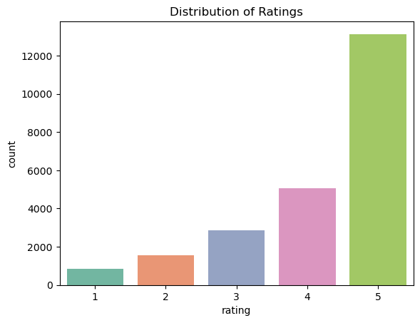

```python
import seaborn as sns
import matplotlib.pyplot as plt

sns.countplot(x='rating', data=df,palette="Set2")
plt.title('Distribution of Ratings')
plt.show()
```

## Insight :

### The majority of customers rated products with a 5, indicating a high level of satisfaction. Ratings decrease progressively from 4 to 1, showing that negative feedback is minimal. Overall, the data suggests that most users had a positive experience with their purchases.

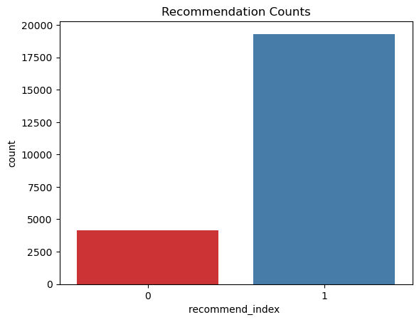

```python
sns.countplot(x='recommend_index ', data=df,palette="Set1")
plt.title('Recommendation Counts')
plt.show()
```

## Insight :

### A large majority of customers (represented by recommend_index = 1) recommended the product, while only a small portion did not (recommend_index = 0). This indicates high customer approval and overall positive sentiment toward the clothing items reviewed.

## Age Distribution

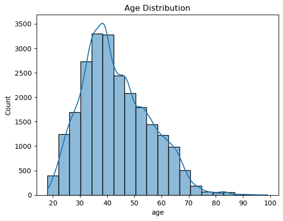

```python
sns.histplot(df['age'], bins=20, kde=True)
plt.title('Age Distribution')
plt.show()
```

## Insight :

### Most reviewers fall between the ages of 30 and 50, with a noticeable peak around the mid-30s. This suggests that middle-aged women are the most active reviewers of women’s clothing products on Amazon. Very few reviews come from users under 20 or over 70, indicating limited engagement from younger and older age groups.

# Average Rating per Department

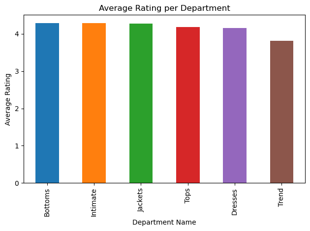

```python
# Define a custom color palette (you can modify these colors)
palette = ['#1f77b4', '#ff7f0e', '#2ca02c', '#d62728', '#9467bd', '#8c564b']

# Group by department and plot average ratings
df.groupby('department_name')['rating'].mean().sort_values(ascending=False).plot(
    kind='bar',
    color=palette
)

plt.title('Average Rating per Department')
plt.ylabel('Average Rating')
plt.xlabel('Department Name')
plt.xticks(rotation=90)
plt.tight_layout()
plt.show()
```

## Insight :

### All departments have high average ratings, with ‘Intimate’ and ‘Bottoms’ rated the highest. ‘Trend’ has the lowest average rating, suggesting slightly lower customer satisfaction in that category.

## Recommendation Rate by Class

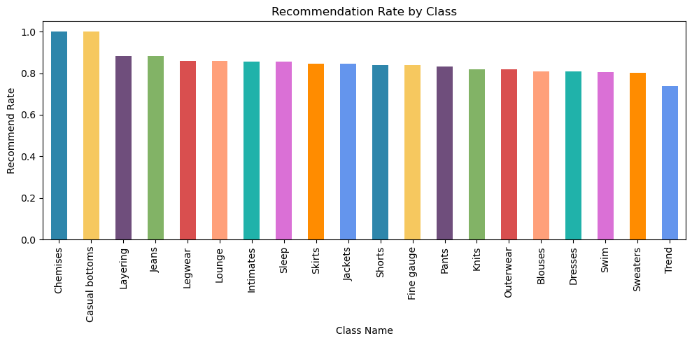

```python
#Define a color palette (extend or customize as needed)
palette = ['#2E86AB', '#F6C85F', '#6F4E7C', '#82B366', '#D94F4F', '#FFA07A', '#20B2AA', '#DA70D6', '#FF8C00', '#6495ED']

# Clean column name (remove extra space if needed)
df.columns = df.columns.str.strip()

# Calculate recommendation rate
rec_rate = df.groupby('class_name')['recommend_index'].mean().sort_values(ascending=False)

# Plot bar chart with color palette
rec_rate.plot(kind='bar', figsize=(10, 5), color=palette[:len(rec_rate)])

plt.title('Recommendation Rate by Class')
plt.ylabel('Recommend Rate')
plt.xlabel('Class Name')
plt.xticks(rotation=90)
plt.tight_layout()
plt.show()
```

## Insight :

### Chemises and Casual Bottoms have the highest recommendation rates, indicating strong customer satisfaction in these categories. On the other hand, Trend has the lowest recommendation rate, suggesting potential areas for product improvement or mismatch with customer expectations.

```python
df.columns
```

```
Index(['age', 'division_name', 'department_name', 'class_name', 'clothing_id',
       'title', 'review_text', 'alike_feedback_count', 'rating',
       'recommend_index'],
      dtype='object')
```

## Review Distribution by Division Name

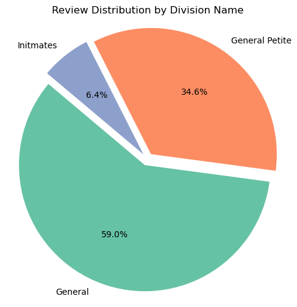

```python
# Count values
division_counts = df['division_name'].value_counts()

# Plot pie chart
plt.figure(figsize=(6, 6))
plt.pie(
    division_counts,
    labels=division_counts.index,
    autopct='%1.1f%%',
    startangle=140,
    colors=plt.cm.Set2.colors,
    explode=[0.05] * len(division_counts)  # Slightly explode all slices
)
plt.title('Review Distribution by Division Name')
plt.axis('equal')  # Make pie chart a circle
plt.show()
```

## Insight :

### Most reviews are for the General division (59%), with fewer for General Petite (34.6%) and very few for Intimates (6.4%).

# Heat Map

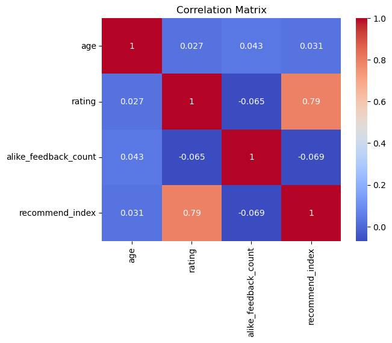

```python
corr = df[['age', 'rating', 'alike_feedback_count', 'recommend_index']].corr()

sns.heatmap(corr, annot=True, cmap='coolwarm')
plt.title('Correlation Matrix')
plt.show()
```

## Insight :

### • Rating and recommend_index are strongly correlated (0.79).

### • Other variables (age, alike_feedback_count) have very low or no correlation with the rest.

### • Most relationships are weak except rating ↔ recommend_index.

```python
df.columns
```

```
Index(['age', 'division_name', 'department_name', 'class_name', 'clothing_id',
       'title', 'review_text', 'alike_feedback_count', 'rating',
       'recommend_index'],
      dtype='object')
```

```python
df['review_text'] = df['review_text'].astype(str)
```

## POLARITY BASED SENTIMENT MAPPING

```python
# 4. Sentiment Analysis using TextBlob Polarity
df['polarity'] = df['review_text'].apply(lambda x: TextBlob(x).sentiment.polarity)
df['sentiment'] = df['polarity'].apply(lambda x: 'Positive' if x > 0 else ('Negative' if x < 0 else 'Neutral'))

# Encode sentiment: Positive = 1, Negative = 0
df['sentiment_label'] = df['sentiment'].map({'Positive': 1, 'Negative': -1 ,"Neutral":0})

# Preview
df[['review_text', 'polarity', 'sentiment', 'sentiment_label']].head()
```

|  | review_text | polarity | sentiment | sentiment_label |
| --- | --- | --- | --- | --- |
| 0 | Like other reviewers i was hesitant to spend t... | 0.300000 | Positive | 1 |
| 1 | As is true of a bunch of the fall clothing pho... | 0.259896 | Positive | 1 |
| 2 | I so wanted this skirt to work, love the desig... | 0.108333 | Positive | 1 |
| 3 | Love love this! i was hesitant to buy this at ... | 0.390104 | Positive | 1 |
| 4 | I absolutely love the retro look of this swims... | 0.173333 | Positive | 1 |

```python
df["sentiment_label"].unique()
```

```
array([ 1, -1,  0], dtype=int64)
```

## PREPROCESSING TEXT DATA

```python
# Text Cleaning + Lemmatization
lemmatizer = WordNetLemmatizer()
stop_words = set(stopwords.words('english'))

def wordopt(review_text):  # creating function to process text
    text = review_text.lower()
    text = re.sub(r'\[.*?\]', '', review_text)
    text = re.sub(r'\W', ' ', review_text)
    text = re.sub(r'https?://\S+|www\.\S+', '', review_text)
    text = re.sub(r'<.*?>+', '', review_text)
    text = re.sub(f'[{re.escape(string.punctuation)}]', '', review_text)
    text = re.sub(r'\n', '', review_text)
    text = re.sub(r'\w*\d\w*', '', review_text)

    # Tokenize
    tokens = nltk.word_tokenize(review_text)

    # Remove stopwords and lemmatize
    stop_words = set(stopwords.words('english'))
    lemmatized = [lemmatizer.lemmatize(word) for word in tokens if word not in stop_words]

    return " ".join(lemmatized)
```

```python
df['review_text']=df['review_text'].apply(wordopt)
```

## WORD CLOUD

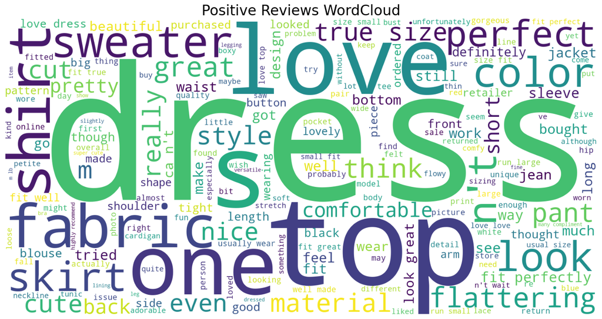

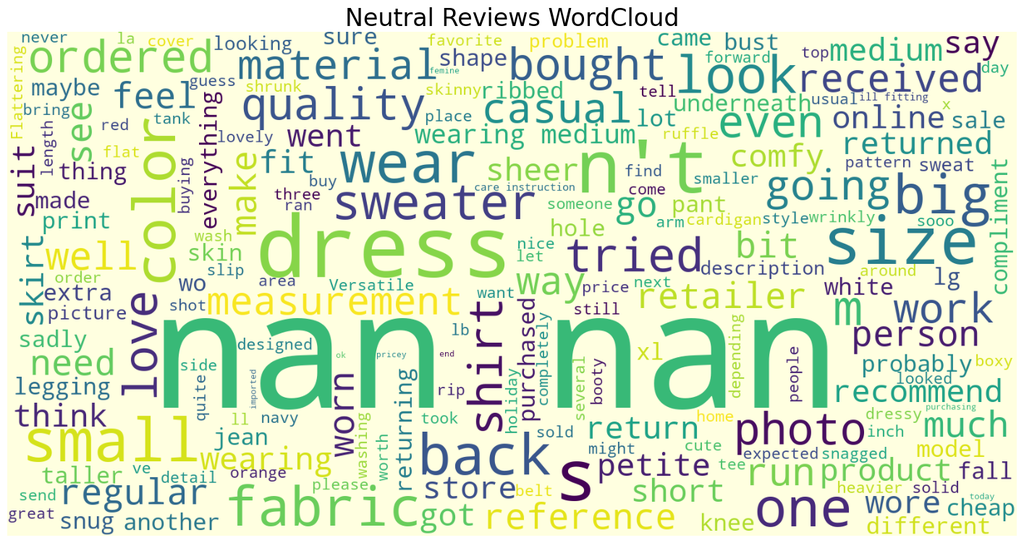

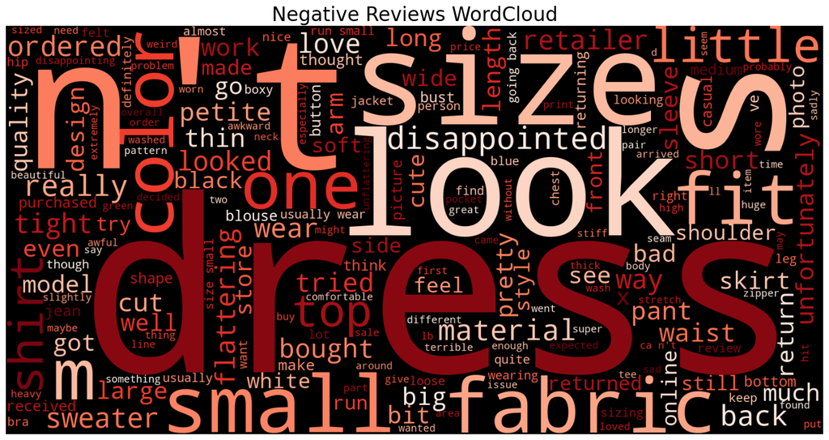

```python
from wordcloud import WordCloud
import matplotlib.pyplot as plt

# Create separate text blocks for each sentiment
positive_text = " ".join(df[df['sentiment'] == 'Positive']['review_text'])
neutral_text  = " ".join(df[df['sentiment'] == 'Neutral']['review_text'])
negative_text = " ".join(df[df['sentiment'] == 'Negative']['review_text'])

# Plot Positive WordCloud
plt.figure(figsize=(18, 10))
plt.imshow(WordCloud(background_color='white', width=1600, height=800).generate(positive_text))
plt.axis('off')
plt.title("Positive Reviews WordCloud", fontsize=24)
plt.show()

# Plot Neutral WordCloud
plt.figure(figsize=(18, 10))
plt.imshow(WordCloud(background_color='lightyellow', width=1600, height=800).generate(neutral_text))
plt.axis('off')
plt.title("Neutral Reviews WordCloud", fontsize=24)
plt.show()

# Plot Negative WordCloud
plt.figure(figsize=(18, 10))
plt.imshow(WordCloud(background_color='black', colormap='Reds', width=1600, height=800).generate(negative_text))
plt.axis('off')
plt.title("Negative Reviews WordCloud", fontsize=24)
plt.show()
```

## TRAIN-TEST SPLIT

```python
# 6. TF-IDF Vectorization
X = df['review_text']
y = df['sentiment_label']

# Split data
X_train, X_test, y_train, y_test = train_test_split(X, y, test_size=0.2, random_state=42)
```

## VECTORIZATION

```python
# TF-IDF Vectorizer
vectorizer = TfidfVectorizer(max_features=5000)
X_train_vec = vectorizer.fit_transform(X_train)
X_test_vec = vectorizer.transform(X_test)
```

## MODEL EVALUATION

```python
# Logistic Regression
lr_model = LogisticRegression()
lr_model.fit(X_train_vec, y_train)
lr_pred = lr_model.predict(X_test_vec)

# Decision Tree
dt_model = DecisionTreeClassifier()
dt_model.fit(X_train_vec, y_train)
dt_pred = dt_model.predict(X_test_vec)

# Random Forest
rf_model = RandomForestClassifier()
rf_model.fit(X_train_vec, y_train)
rf_pred = rf_model.predict(X_test_vec)

# Linear SVC
svm_model = LinearSVC()
svm_model.fit(X_train_vec, y_train)
svm_pred = svm_model.predict(X_test_vec)
```

```python
def evaluate_model(name, y_true, y_pred):
    print(f"----- {name} -----")
    print("Accuracy:", accuracy_score(y_true, y_pred))
    print("Classification Report:\n", classification_report(y_true, y_pred))
```

```python
evaluate_model("Logistic Regression", y_test, lr_pred)
evaluate_model("Decision Tree", y_test, dt_pred)
evaluate_model("Random Forest", y_test, rf_pred)
evaluate_model("Linear SVC", y_test, svm_pred)
```

```
----- Logistic Regression -----
Accuracy: 0.9525329927628778
Classification Report:
               precision    recall  f1-score   support

          -1       0.90      0.22      0.35       258
           0       1.00      0.92      0.96       185
           1       0.95      1.00      0.97      4255

    accuracy                           0.95      4698
   macro avg       0.95      0.71      0.76      4698
weighted avg       0.95      0.95      0.94      4698

----- Decision Tree -----
Accuracy: 0.9163473818646233
Classification Report:
               precision    recall  f1-score   support

          -1       0.26      0.24      0.25       258
           0       0.94      0.93      0.93       185
           1       0.95      0.96      0.95      4255

    accuracy                           0.92      4698
   macro avg       0.72      0.71      0.71      4698
weighted avg       0.91      0.92      0.91      4698

----- Random Forest -----
Accuracy: 0.941890166028097
Classification Report:
               precision    recall  f1-score   support

          -1       0.00      0.00      0.00       258
           0       1.00      0.92      0.96       185
           1       0.94      1.00      0.97      4255

    accuracy                           0.94      4698
   macro avg       0.65      0.64      0.64      4698
weighted avg       0.89      0.94      0.92      4698

----- Linear SVC -----
Accuracy: 0.9587058322690507
Classification Report:
               precision    recall  f1-score   support

          -1       0.79      0.41      0.54       258
           0       1.00      0.92      0.96       185
           1       0.96      0.99      0.98      4255

    accuracy                           0.96      4698
   macro avg       0.92      0.77      0.83      4698
weighted avg       0.95      0.96      0.95      4698
```

## PERFORMANCE ANALYSIS ON EACH MODEL

```python
# Initialize models
LR = LogisticRegression(max_iter=1000)
RF = RandomForestClassifier()
DT = DecisionTreeClassifier()
SVC = LinearSVC()

# Store accuracies
test_accuracies = []
train_accuracies = []

models = [LR, SVC , RF, DT]
names = ['Logistic Regression', 'Linear SVC', 'Random Forest', 'Decision Tree']

for model in models:
    model.fit(X_train_vec, y_train)
    test_acc = round(accuracy_score(y_test, model.predict(X_test_vec)) * 100, 2)
    train_acc = round(accuracy_score(y_train, model.predict(X_train_vec)) * 100, 2)
    test_accuracies.append(test_acc)
    train_accuracies.append(train_acc)

# Display comparison
for name, train, test in zip(names, train_accuracies, test_accuracies):
    print(f"{name} → Train Accuracy: {train}% | Test Accuracy: {test}%")
```

```
Logistic Regression → Train Accuracy: 96.01% | Test Accuracy: 95.25%
Linear SVC → Train Accuracy: 98.76% | Test Accuracy: 95.87%
Random Forest → Train Accuracy: 100.0% | Test Accuracy: 94.21%
Decision Tree → Train Accuracy: 100.0% | Test Accuracy: 91.44%
```

# Model Selection

### In this sentiment analysis project on Amazon Women’s Clothing Reviews, Linear SVC proved to be the most effective model. With a training accuracy of 98.76% and test accuracy of 95.87%, it outperformed other models by maintaining high performance without overfitting. This makes it the best choice for accurately predicting customer sentiment.

## CONCLUSION

- The Amazon Women’s Clothing Reviews Sentiment Analysis project demonstrates the power of natural language processing and machine learning in understanding customer opinions at scale.
- By analyzing user-generated review text, this project successfully classifies sentiments and uncovers meaningful patterns in customer feedback.
- The insights gained from this analysis can help businesses enhance product quality, improve customer satisfaction, and make data-driven marketing decisions.
- Overall, sentiment analysis not only streamlines the review evaluation process but also adds measurable value to both consumers and retailers in the competitive e-commerce landscape.
- Among the models evaluated, Linear Support Vector Classifier (Linear SVC) was identified as the best-performing model, achieving the highest test accuracy while maintaining a strong balance between performance and generalization. This makes it the most reliable choice for accurately predicting customer sentiment in this project.